# Hotel Strategies

Hejun Chen

2022-12-15

## R packages

```r
library(tidyverse)
library(magrittr)
library(dplyr)
library(tidyr)
library(readr)
library(pander)
theme_set(theme_bw())
```

# **Main Question: What strategies can the hotel implement to increase revenues?**

## **Get the data**

```r
# read the data and show the first five rows
df <- read_csv("hotel_bookings.csv")
df %>% head(5)
```

```
## # A tibble: 5 × 32
##   hotel        is_canceled lead_time arrival_date_ye… arrival_date_mo… arrival_date_we…
##   <chr>              <dbl>     <dbl>            <dbl> <chr>                       <dbl>
## 1 Resort Hotel           0       342             2015 July                           27
## 2 Resort Hotel           0       737             2015 July                           27
## 3 Resort Hotel           0         7             2015 July                           27
## 4 Resort Hotel           0        13             2015 July                           27
## 5 Resort Hotel           0        14             2015 July                           27
## # … with 26 more variables: arrival_date_day_of_month <dbl>,
## #   stays_in_weekend_nights <dbl>, stays_in_week_nights <dbl>, adults <dbl>,
## #   children <dbl>, babies <dbl>, meal <chr>, country <chr>,
## #   market_segment <chr>, distribution_channel <chr>, is_repeated_guest <dbl>,
## #   previous_cancellations <dbl>, previous_bookings_not_canceled <dbl>,
## #   reserved_room_type <chr>, assigned_room_type <chr>, booking_changes <dbl>,
## #   deposit_type <chr>, agent <chr>, company <chr>, …
```

## Hotel Type:

City hotels are more popular than resort hotels

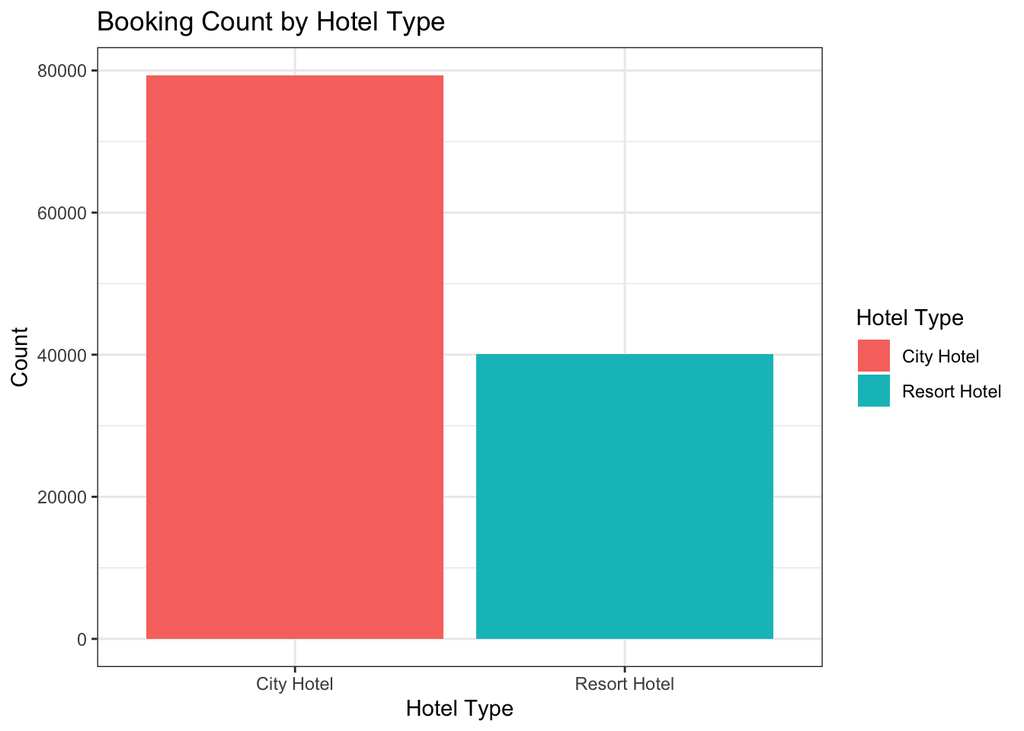

```r
# Create barplots to compare sales through different hotel types
df %>% count(hotel) %>% ggplot() +
  aes(x = hotel, y = n, fill = hotel) +
  geom_bar(stat = 'identity') +
  theme_bw() +
  labs(x = "Hotel Type",
       y = "Count",
       title = "Booking Count by Hotel Type",
       fill = "Hotel Type")
```

## Cancellation rate:

Overall cancelation rate is near 40%, which is very high

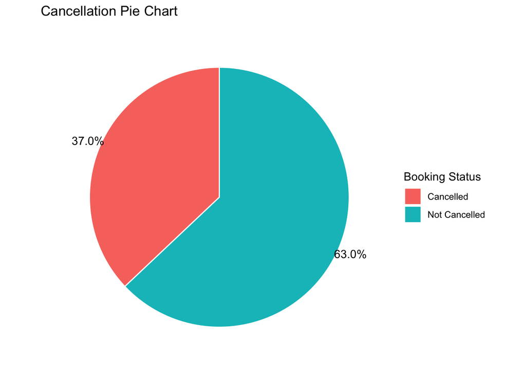

```r
# Replace numeric indicators with specific string values
df$is_canceled[df$is_canceled == 0] <- "Not Cancelled"
df$is_canceled[df$is_canceled == 1] <- "Cancelled"
cancel <- df %>%
        group_by(is_canceled) %>%
         tally() %>%
          mutate(perc = n / sum(n))

# Plot a pie chart to visualization cancellation rate
ggplot(cancel, aes(x = "", y = perc, fill = is_canceled)) +
  geom_bar(width = 1, stat = "identity", color = 'white') +
  coord_polar("y", start=0) +
  theme(axis.text.x = element_blank()) +
  geom_text(aes(x = 1.6, label = scales::percent(perc, accuracy = .1)),
            position = position_stack(vjust = .5)) +
  theme_void() +
  labs(title = "Cancellation Pie Chart",
       fill = "Booking Status")
```

## Bookings by country:

We can see that a large proportion (~40%) of bookings are from Portugal, and then Great Britain(10%).

```r
# Create a table to show percentage of bookings by country
df %>% count(country) %>%
  mutate(percentage = round(100 * n / sum(n),1)) %>%
  arrange(desc(percentage)) %>%
  head(5) %>%
  pander
```

| country | n | percentage |
| --- | --- | --- |
| PRT | 48590 | 40.7 |
| GBR | 12129 | 10.2 |
| FRA | 10415 | 8.7 |
| ESP | 8568 | 7.2 |
| DEU | 7287 | 6.1 |

## Bookings over time:

Hotel bookings are low during cold months around November ~ February. The bookings nearly double around April to October.

```r
# Create a table to show percentage of bookings by month
df %>% count(arrival_date_month) %>%
  mutate(percentage = round(100 * n / sum(n),1)) %>%
  arrange(desc(percentage)) %>%
  pander
```

| arrival_date_month | n | percentage |
| --- | --- | --- |
| August | 13877 | 11.6 |
| July | 12661 | 10.6 |
| May | 11791 | 9.9 |
| April | 11089 | 9.3 |
| October | 11160 | 9.3 |
| June | 10939 | 9.2 |
| September | 10508 | 8.8 |
| March | 9794 | 8.2 |
| February | 8068 | 6.8 |
| December | 6780 | 5.7 |
| November | 6794 | 5.7 |
| January | 5929 | 5 |

## Bookings by market segment:

Majority of the bookings were made through Online & Offline TA

```r
# Create a table to show percentage of bookings by market segment
df %>% count(market_segment) %>%
  mutate(percentage = round(100 * n / sum(n),1)) %>%
  arrange(desc(percentage)) %>%
  head(5) %>%
  pander
```

| market_segment | n | percentage |
| --- | --- | --- |
| Online TA | 56477 | 47.3 |
| Offline TA/TO | 24219 | 20.3 |
| Groups | 19811 | 16.6 |
| Direct | 12606 | 10.6 |
| Corporate | 5295 | 4.4 |

## Cancellation with lead time:

Customers with a lead_time > 200 days barely actually checked out

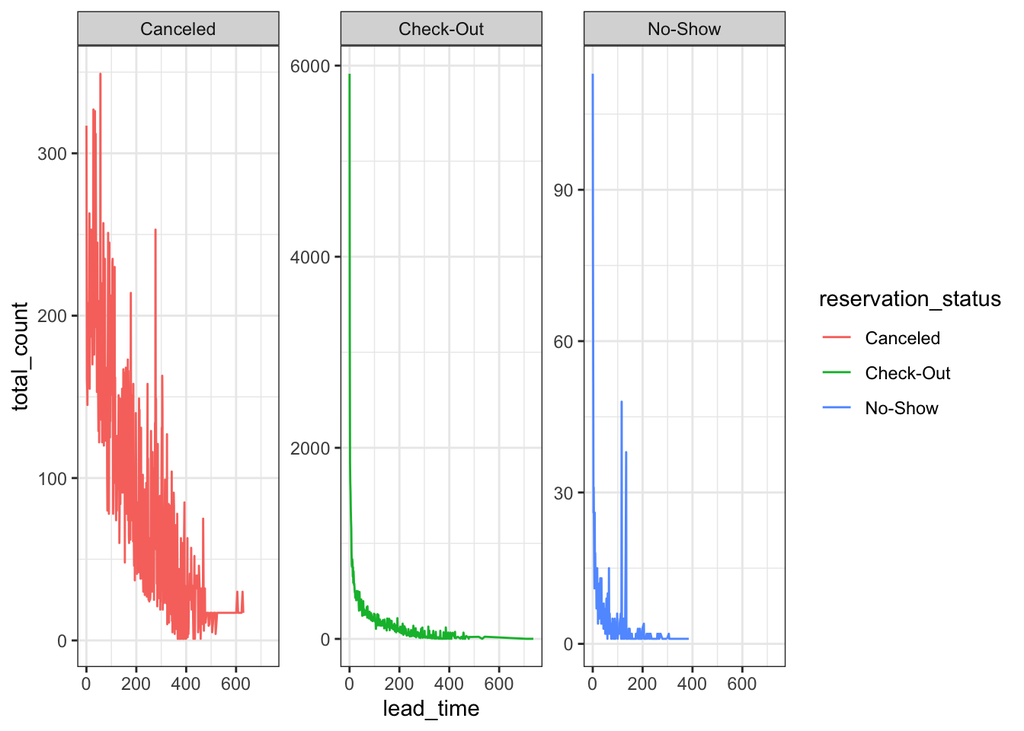

```r
# Create a table to show the count of each reservation_status and lead_time pair
df_leadtime <- df %>%
  group_by(reservation_status, lead_time) %>%
  summarise(total_count = n())

# Plot line plot to show trends of different reservation_status over lead_time
df_leadtime %>%
  ggplot() +
  aes(x = lead_time, y = total_count, color = reservation_status) +
  geom_line() +
  facet_wrap(. ~ reservation_status, scales = "free_y") +
  theme_bw()
```

## Cancellation by market segment:

Bookings made through groups have the highest cancelation rate

```r
# Create a table to show the count of each reservation_status and market_segment pair
df_market_segment <- df %>%
  group_by(market_segment, reservation_status) %>%
  summarise(total_count = n())

# Calculate the cancellation rate within each market_segment
df_market_segment %>%
  group_by(market_segment) %>%
  summarise(reservation_status = reservation_status, total_count = total_count, cancel_percentage = total_count/sum(total_count)) %>%
  filter(reservation_status == "Canceled") %>%
  arrange(desc(cancel_percentage)) %>%
  select(-c("reservation_status")) %>%
  head(5) %>%
  pander
```

`summarise()` has grouped output by ‘market_segment’. You can override using the `.groups` argument.

| market_segment | total_count | cancel_percentage |
| --- | --- | --- |
| Undefined | 2 | 1 |
| Groups | 12023 | 0.6069 |
| Online TA | 20148 | 0.3567 |
| Offline TA/TO | 8080 | 0.3336 |
| Aviation | 41 | 0.173 |

## Customer Loyalty:

Most customers won’t come back after their first purchase

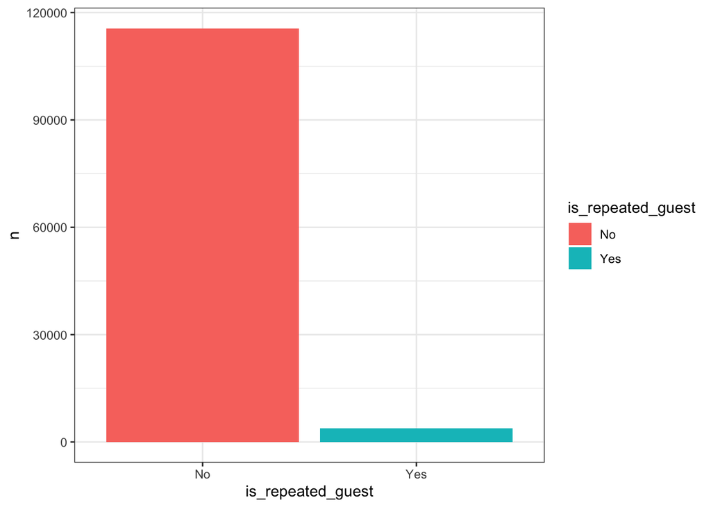

```r
# Replace numeric values with specific string values for easier visualization
df$is_repeated_guest[df$is_repeated_guest == 0] <- "No"
df$is_repeated_guest[df$is_repeated_guest == 1] <- "Yes"

# Plot barplots to show numbers of repeated vs. non-repeated customers
df %>% count(is_repeated_guest) %>%
  ggplot() +
  aes(x = is_repeated_guest, y = n, fill = is_repeated_guest) +
  geom_bar(stat = 'identity')
```

# **Conclusion**

Since we want to increase revenues for the hotels, we should develop strategies to conduct most effective marketing and overbooking, as well as to recover loss from booking cancellations.

**First**, we can invest more money in marketing in Portugal because of its high customer base (~40%), and countries with relatively high customer bases like the Great Britain (~10%) to increase our market shares.

**Third**, since majority of the bookings were made through Online and offline tech assistants, we should train those assistants well so they can provide better/more effective services to our potential customers in the booking process.

**Fourth**, we see that hotels suffer from high cancellation rates. Since customers with a lead time that is more than 200 days barely check-in, we can do overbooking (which means we assume the customers won’t arrive and still sell the booked rooms to new customers.) Also, we see that ~60% of bookings made as groups were cancelled. So, to recover the loss, we can charge a higher cancellation fee if the booking is made by groups.

**Fifth**, we see that we have a very low number of repeated customers, which indicates that we don’t have a good customer loyalty strategy. We should develop strategies like follow-up marketing emails, bonuses for returning customers, etc. to attract our old customers and thus gain a larger market growth.